# Air pollution and Lung Cancer (CaseMed Example)

## Summary data for lung cancer

Similar to the FPM data, I will look at summary stats for each column in the dataset. I will then graph incidence and mortality by state to understand the variation.

```r
#Get summary stats from the data
summary(lungClean)
```

```
##     State           Mortality_Incidence_Ratio   Mortality       Incidence
##  Length:51          Min.   :0.5960            Min.   :18.92   Min.   :25.75
##  Class :character   1st Qu.:0.6830            1st Qu.:35.87   1st Qu.:53.95
##  Mode  :character   Median :0.7080            Median :41.18   Median :58.83
##                     Mean   :0.7028            Mean   :41.69   Mean   :59.37
##                     3rd Qu.:0.7275            3rd Qu.:46.19   3rd Qu.:66.84
##                     Max.   :0.8070            Max.   :64.18   Max.   :90.60
```

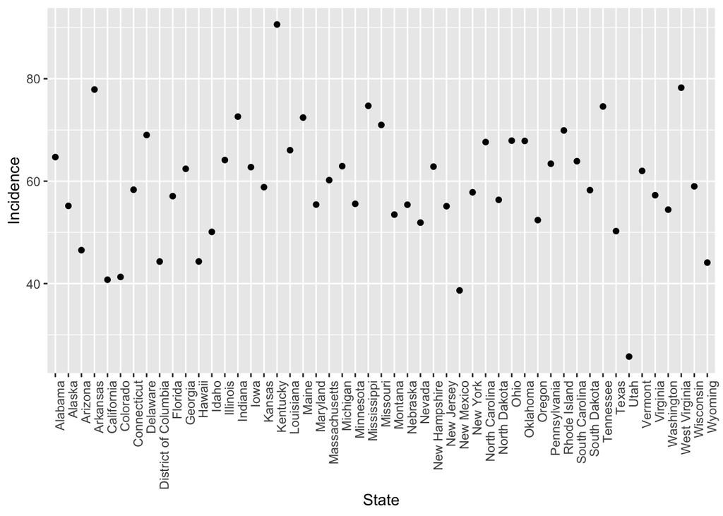

```r
#plot incidence and mortality by state
ggplot(lungClean, aes(x=State, y=Incidence)) +geom_point() +theme(axis.text.x = element_text(angle = 90, hjust = 1))
```

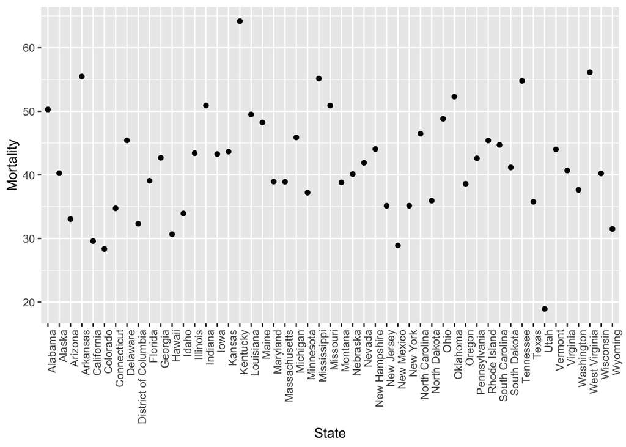

```r
ggplot(lungClean, aes(x=State, y=Mortality)) +geom_point() +theme(axis.text.x = element_text(angle = 90, hjust = 1))
```

There is clear variation between states. We want to know if this variation can be explained by average levels of fine particulate matter in the air. To do this, we need to combine the fpm data with the lung data.

## Merge lung cancer and air pollution data

We will use the merge.data.frame() command to combine lung and fpm data. In both datasets, there is a column with the name State. We will use this column to merge the data together so that we will have information on air pollution and lung cancer for each state.

```r
#combine data sets
allData <- merge.data.frame(lungClean, fpmClean, by="State", all = T)
```

## Air pollution and lung cancer incidence

We want to look at how levels of air pollution correlate to lung cancer incidence using ggplot2:

```
## Warning: Removed 2 rows containing missing values (geom_point).
```

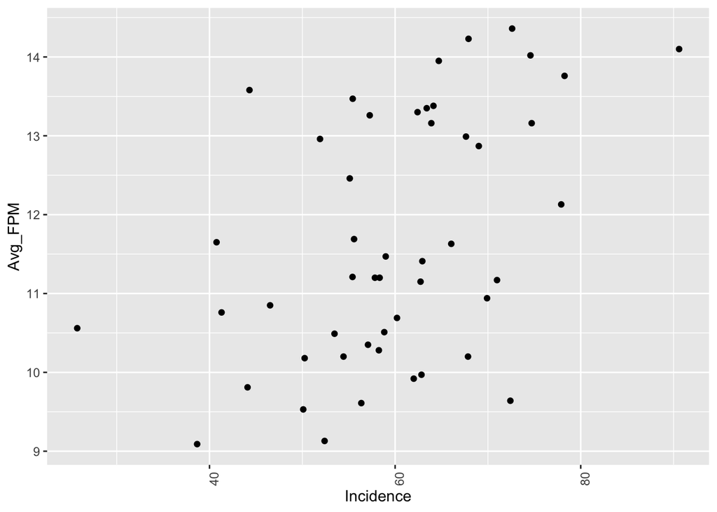

```r
ggplot(allData, aes(x=Incidence, y=Avg_FPM)) +geom_point() +theme(axis.text.x = element_text(angle = 90, hjust = 1))
```

Notice the warning message: removed 2 rows containing missing values. Alaska and Hawaii do not have FPM information, so ggplot had to remove these rows.

If you have NAs in your data, they can cause problems, so you can remove NA values in your data set by using na.omit (make sure to reference this in your methods). You also could use allData <- merge.data.frame(lungClean, fpmClean, by=“State”, all = FALSE) when merging your data. Setting all=FALSE instead of TRUE will drop rows that are not included in both datasets.

## Linear regression model for air pollution and lung cancer incidence

We want to know if the trend we see between air pollution and lung cancer incidence is statistically significant. We will use a simple regression model to test. We will fit the model with the lm() command, and then will graph the data, trend line, and key statistics.

The ggplot code is a bit more intense, but the first line is to plot the fpm and lung cancer incidence data which is embedded in the incidenceFPMFit model. Next we add the regression line with stat_smooth(). The last portion goes to extracting stats from the linear model. If you just want the stats from your model, these can be found via summary(incidenceFPMFit) as shown below.

```r
incidenceFPMFit <- lm(Incidence ~ Avg_FPM, data = allData)

summary(incidenceFPMFit)
```

```
##
## Call:
## lm(formula = Incidence ~ Avg_FPM, data = allData)
##
## Residuals:
##      Min       1Q   Median       3Q      Max
## -30.1820  -4.3128  -0.1295   4.9902  22.2628
##
## Coefficients:
##             Estimate Std. Error t value Pr(>|t|)
## (Intercept)  18.9040    11.2948   1.674  0.10083
## Avg_FPM       3.5060     0.9609   3.649  0.00066 ***
## ---
## Signif. codes:  0 '***' 0.001 '**' 0.01 '*' 0.05 '.' 0.1 ' ' 1
##
## Residual standard error: 10.38 on 47 degrees of freedom
##   (2 observations deleted due to missingness)
## Multiple R-squared:  0.2207, Adjusted R-squared:  0.2041
## F-statistic: 13.31 on 1 and 47 DF,  p-value: 0.0006595
```

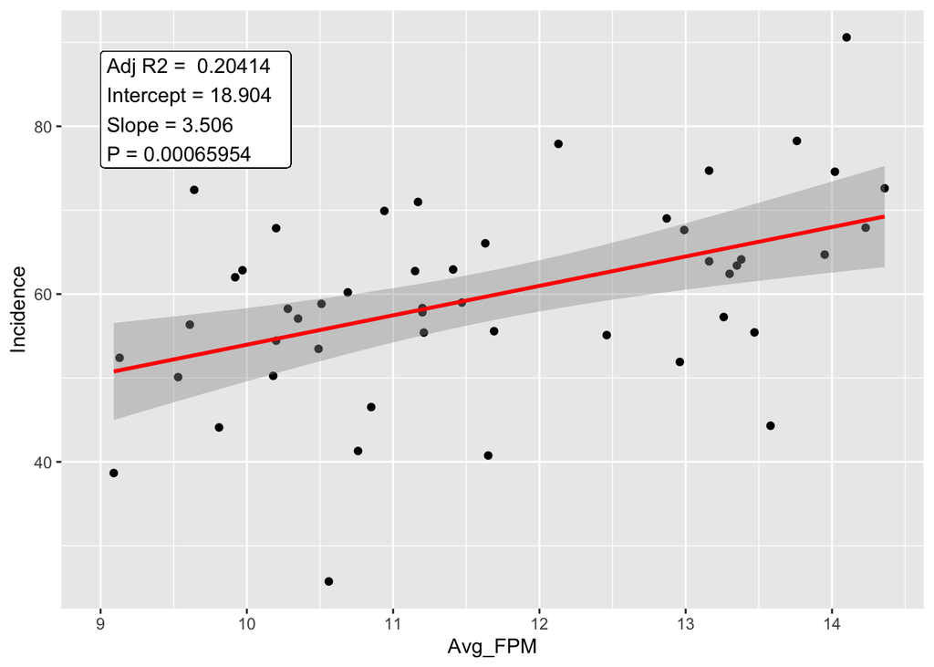

```r
ggplot(incidenceFPMFit$model, aes_string(x = names(incidenceFPMFit$model)[2], y = names(incidenceFPMFit$model)[1])) +
  geom_point() +
  stat_smooth(method = "lm", col = "red") +
  geom_label(aes(x = 9, y = 82), hjust = 0,
             label = paste("Adj R2 = ",signif(summary(incidenceFPMFit)$adj.r.squared, 5),
                           "\nIntercept =",signif(incidenceFPMFit$coef[[1]],5 ),
                           " \nSlope =",signif(incidenceFPMFit$coef[[2]], 5),
                           " \nP =",signif(summary(incidenceFPMFit)$coef[2,4], 5)))
```

You can see that the p value is less than 0.05, meaning the correlation is statistically significant. The R^2 value is low, meaning the air pollution only contributes to a fraction of the variation seen in lung cancer incidence by state.

## Linear regression model for air pollution and lung cancer mortality

We repeat the above steps with mortality.

```r
mortalityFPMFit <- lm(Mortality ~ Avg_FPM, data = allData)

summary(mortalityFPMFit)
```

```
##
## Call:
## lm(formula = Mortality ~ Avg_FPM, data = allData)
##
## Residuals:
##      Min       1Q   Median       3Q      Max
## -20.0829  -4.8304  -0.3915   4.7884  15.6586
##
## Coefficients:
##             Estimate Std. Error t value Pr(>|t|)
## (Intercept)   10.631      8.158   1.303 0.198887
## Avg_FPM        2.687      0.694   3.872 0.000333 ***
## ---
## Signif. codes:  0 '***' 0.001 '**' 0.01 '*' 0.05 '.' 0.1 ' ' 1
##
## Residual standard error: 7.496 on 47 degrees of freedom
##   (2 observations deleted due to missingness)
## Multiple R-squared:  0.2418, Adjusted R-squared:  0.2257
## F-statistic: 14.99 on 1 and 47 DF,  p-value: 0.0003327
```

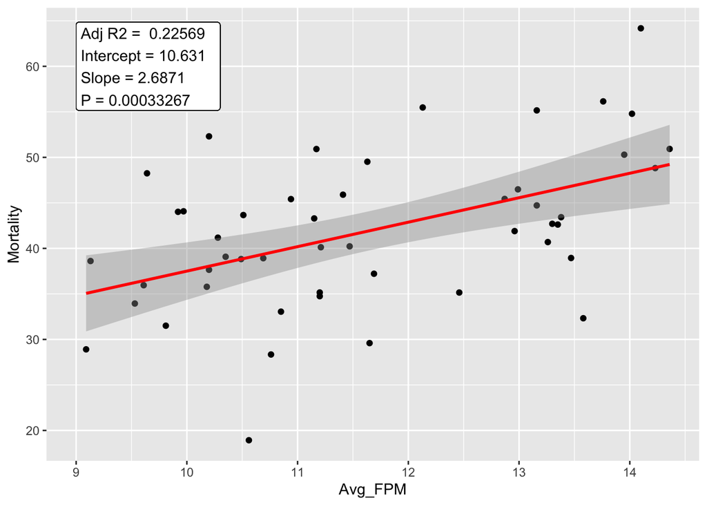

```r
ggplot(mortalityFPMFit$model, aes_string(x = names(mortalityFPMFit$model)[2], y = names(mortalityFPMFit$model)[1])) +
  geom_point() +
  stat_smooth(method = "lm", col = "red") +
  geom_label(aes(x = 9, y = 60), hjust = 0,
             label = paste("Adj R2 = ",signif(summary(mortalityFPMFit)$adj.r.squared, 5),
                           "\nIntercept =",signif(mortalityFPMFit$coef[[1]],5 ),
                           " \nSlope =",signif(mortalityFPMFit$coef[[2]], 5),
                           " \nP =",signif(summary(mortalityFPMFit)$coef[2,4], 5)))
```

Here we see similar results as the incidence, meaning mortality is also correlated with air pollution.

Questions? Feel free to email ekk19 @ case.edu.